# chromosomix against reference implementations: time

A map and a track from a file to a picture in three viewers, and every command of the validation, run again and timed

The commands are [the validation](https://chromosomix.app/validation/)’s, as it ran them. Beside this page: `viewers.tsv`, every picture timed in a viewer, and `timings.tsv`, every timed command, one row each.

The page is in two parts. The first, **Time to a picture**, times three viewers — chromosomix, juicebox.js and HiGlass — drawing the same contact map and one track beside it, at the same resolution, from files on this machine and from the bucket they are published in. The second, from **The machine** on, times the analyses: [`validation.qmd`](https://chromosomix.app/validation/) runs each analysis twice, through `chromosomix` and through the package it reproduces, and writes every command it ran to `notebooks/work/validation/commands.json`. This notebook runs each of them again, exactly as written there but writing to a scratch folder, as a fresh process, `RUNS` times round robin (four, unless `TIMING_RUNS` in the environment says otherwise), the two sides of each pair taking turns to go first, and measures what each run costs: its **CPU time**, user and system, of the process and of every process it started and waited for; its **wall-clock time**; and its **peak memory**, the most those processes held together: their proportional set sizes — a page two of them share counted half in each, so that a pool of forked workers is not counted again in every worker — added up four times a second while the command runs, and never less than the largest resident set any one of them reached, which a sample can miss. A reference that runs four processes holds what the four hold. Where the system does not list a process’s children, as macOS does not, the peak memory is that largest resident set alone.

Every run of a command is one line of **`notebooks/work/validation/timings.tsv`**, a tidy table — one row per command and run, one column per variable, the machine and the versions included — and every picture a viewer was timed on is one line of **`viewers.tsv`** beside it, in the same form; every table and figure below is drawn from those two.

**To render.** Render `validation.qmd` first: it fetches the data, makes every input and writes the command list. The viewers need the app built, the two viewers and a browser for them, and higlass-python’s environment (`notebooks/requirements-higlass.txt`, with libfuse 2 for its URLs). Then, in the same environment and on a machine left otherwise idle:

```bash
npm run build                                       # the app, served from dist/
npm ci --prefix notebooks/viewers                   # juicebox.js, HiGlass and Playwright, pinned
npx --prefix notebooks/viewers playwright install chromium
python -m venv higlass-env && higlass-env/bin/pip install -r notebooks/requirements-higlass.txt
QUARTO_PYTHON=refs/bin/python quarto render notebooks/timing.qmd
```

The viewers’ files (about 15 GB, most of it the mouse map in its two formats) are fetched once into `notebooks/work/viewers/data/`.

A second render reads the tables rather than timing again (`REDO`, `REDO_VIEWERS`), unless the command list, the pictures, the number of runs or the `chromosomix` build has changed. `.github/workflows/notebooks.yml` renders both notebooks on every release, on a fresh GitHub runner each time, and publishes this page at https://chromosomix.app/timings/ with the two tables beside it; the block under the title says which render, and which machine, this is.

```python
from pathlib import Path
import os

#: Timed runs of each command (TIMING_RUNS overrides it for a quick look), and whether to time them again.
#: Even, so that each side of a pair goes first in as many rounds as the other (`round_of`).
RUNS = int(os.environ.get('TIMING_RUNS', 4))
REDO = False

HERE = Path.cwd().resolve()
REPO = HERE.parent if HERE.name == 'notebooks' else HERE
WORK = REPO / 'notebooks' / 'work' / 'validation'
MANIFEST = WORK / 'commands.json'
TIMINGS = WORK / 'timings.tsv'
SCRATCH = WORK / 'timing'

#: Runs of each picture in each viewer (VIEWER_RUNS overrides it), and whether to time them again.
#: Four, so that each of the four viewers goes first in one round of each picture (`viewer_plan.ordered`).
VIEWER_RUNS = int(os.environ.get('VIEWER_RUNS', 4))
REDO_VIEWERS = False
#: The app's build (`npm run build`), served from loopback as the site serves it.
APP_BUILD = REPO / 'dist'
#: higlass-python's environment (notebooks/requirements-higlass.txt), relative to the repository or absolute.
HIGLASS_PYTHON = Path(os.environ.get('HIGLASS_PYTHON', 'higlass-env/bin/python'))
HIGLASS_PYTHON = HIGLASS_PYTHON if HIGLASS_PYTHON.is_absolute() else REPO / HIGLASS_PYTHON
VWORK = REPO / 'notebooks' / 'work' / 'viewers'
VDATA = VWORK / 'data'
VIEWER_PLAN = VWORK / 'plan.json'
VIEWER_RESULTS = VWORK / 'results.jsonl'
VIEWER_SHOTS = VWORK / 'pictures'
VIEWER_TABLE = WORK / 'viewers.tsv'
```

```python
import hashlib
import json
import platform
import shlex
import shutil
import subprocess
import sys
import tempfile
import threading
import time
import urllib.parse
import urllib.request
from collections import Counter
from itertools import groupby

import matplotlib.pyplot as plt
import numpy as np
import pandas as pd
from matplotlib.ticker import FuncFormatter, NullLocator

APP_COLOUR, REF = '#2a78d6', '#eb6834'
INK, INK2, GRID, SURFACE, MISSING = '#0b0b0b', '#52514e', '#e7e6e2', '#fcfcfb', '#efeeea'
plt.rcParams.update({
    'figure.facecolor': SURFACE, 'axes.facecolor': SURFACE, 'savefig.facecolor': SURFACE,
    'axes.edgecolor': INK2, 'axes.labelcolor': INK, 'xtick.color': INK2, 'ytick.color': INK2,
    'text.color': INK, 'axes.spines.top': False, 'axes.spines.right': False,
    'axes.grid': True, 'grid.color': GRID, 'grid.linewidth': 0.6, 'axes.axisbelow': True,
    'lines.linewidth': 2, 'font.size': 9, 'axes.titlesize': 10, 'axes.titleweight': 'bold',
    'axes.titlelocation': 'left', 'legend.frameon': False, 'figure.dpi': 110,
})


def show(frame, precision=2, **formats):
    """A table without row numbers: the columns named in `formats` their way, the others to `precision`."""
    return frame.style.hide(axis='index').format(formats or None, precision=precision)


def measures(values):
    """Named numbers as a two-column table."""
    return pd.DataFrame(list(values.items()), columns=['measure', 'value']).style.hide(axis='index')


def machine():
    """What the times were measured on, as columns of the table."""
    cpu = platform.processor()
    if Path('/proc/cpuinfo').exists():
        cpu = next((line.split(':', 1)[1].strip() for line in open('/proc/cpuinfo') if line.startswith('model name')), cpu)
    try:
        memory = round(os.sysconf('SC_PAGE_SIZE') * os.sysconf('SC_PHYS_PAGES') / 1e9, 1)
    except (ValueError, OSError):
        memory = np.nan
    node = subprocess.run(['node', '--version'], capture_output=True, text=True).stdout.strip()
    return {'processor': cpu, 'cores': os.cpu_count(), 'memory_gb': memory, 'system': platform.platform(),
            'node': node, 'python': platform.python_version()}


MACHINE = machine()
#: Whether the system lists a process's children and its proportional set size, as Linux does: where it does
#: not, as macOS does not, a run's peak memory is that of its largest process alone.
WEIGHS = (Path(f'/proc/self/task/{threading.get_native_id()}/children').exists()
          and Path('/proc/self/smaps_rollup').exists())
#: How often, in seconds, a run's processes are weighed while it runs.
EVERY = 0.25
```

## Time to a picture

How long a reader waits between handing a viewer a contact map with a track and seeing them drawn, in chromosomix and in the two viewers most used for the same thing: juicebox.js, the browser form of Juicebox, which reads a `.hic`, and [HiGlass](https://github.com/higlass/higlass), which reads an `.mcool` through a tile server — here the one higlass-python starts for a file it is given. chromosomix reads both formats and is timed on each; juicebox.js reads no `.mcool` and HiGlass no `.hic`. Every picture is **one map and one track**, the same files in every viewer, and it is timed from the moment the viewer is handed them, with the view, to the moment the viewer itself says the picture is finished:

- **chromosomix**: its own report of a finished picture (`chromosomix:rendered`, SPECS §12), sent once every map on screen has been painted from its data, at the resolution the report names, and every track beside it drawn;
- **juicebox.js**: no spinner, the map’s last repaint covering the state it was asked for, and the track holding a tile along each axis, nothing still updating;
- **HiGlass**: every tile of both tracks that is in view fetched and drawn.

**At one resolution, the plan’s.** No viewer chooses the resolution. chromosomix is handed a workspace naming the map at its rung (`map.mcool::/resolutions/25000`); juicebox.js an explicit state, with the resolution’s place in the file’s list, the window’s first bin and the pixels a bin is drawn at, which fit the window to its map; HiGlass the window, and the rung as its heatmap’s `maxZoom`, its one control over the resolution, which keeps it from going finer. Each answers with the resolution it drew. A picture drawn at another resolution, or of part of the window, is kept as what it was, never as a time for the picture asked for. A view a viewer cannot draw at the plan’s resolution is not run, and the tables say why: a rung the file does not store, or a whole genome, which juicebox.js draws only from the `.hic`’s own whole-genome matrix, at a resolution of its own.

**From disk and from the bucket.** Each picture is timed from files on this machine and from the same files where they are published: 4DN’s open-data bucket (Amazon S3, us-east-1) for the chicken and the mouse, the app’s demo bucket (eu-west-3) for the yeast. From disk, chromosomix and juicebox.js are given the files as a reader’s drop gives them, and HiGlass’s server reads them; before each run from disk the kernel’s page cache is emptied, where the machine lets the benchmark do so (the `page_cache` column), so that the files are read from the disk, as at a first opening. From the bucket, chromosomix and juicebox.js read them by range from the page, and HiGlass’s server through higlass-python’s FUSE mount, which is how it serves a file it does not hold.

**Nothing carried over.** Every run is a fresh browser context — Chromium, driven by Playwright (`notebooks/scripts/viewers.mjs`) — with no cache and no storage, and every HiGlass run meets a server started for it alone, with an empty block cache when it reads from the bucket. The viewer’s page is loaded empty first, with its code and its workers, and that time is kept apart (`app_seconds`): what is timed is the data’s road to the screen. It is then left two seconds, as a reader’s page is while they find their file — what a viewer starts once its page is idle, as chromosomix starts its reader and h5wasm, a reader finds started — and chromosomix, from disk, as long again on the page its workspace leaves asking for the files. Each of `VIEWER_RUNS` rounds (four, unless `VIEWER_RUNS` in the environment says otherwise) draws every picture once, the viewers taking turns to go first, so that the one that reads a file first, from a disk or from a bucket that answers a second read faster, is a different one each round. The requests and bytes counted are those the page asked for between the two moments: of the bucket, for chromosomix and juicebox.js; of its server, for HiGlass, whose own reads go through FUSE, outside the page, and are not counted.

```python
#: Each genome's map, in both formats, and its track: where they are published and their MD5s, and the four
#: views, each at one resolution, of a window of three to five hundred bins on a side.
FOURDN_FILES = 'https://4dn-open-data-public.s3.amazonaws.com/fourfront-webprod/wfoutput'
DEMO_STORE = 'https://rsglab-data.s3.eu-west-3.amazonaws.com/demo/store/yeast'
GENOMES = {
    'yeast': dict(
        data='Micro-C of strain A364A (Costantino et al. 2020, GEO GSE151553) and ATAC-seq: the app’s demo store',
        mcool=(f'{DEMO_STORE}/GSE151553_A364_merged.mcool', '319a04a8d7e41d9eb88e2378ea3ea373'),
        hic=(f'{DEMO_STORE}/GSE151553_A364_merged.hic', 'ce2cf114ff78ab12e8c20b060c92f539'),
        track=(f'{DEMO_STORE}/Yeast_ATAC.bw', '3e326d9b3df621d6d4973d42b81f18de'),
        views=[dict(view='genome', resolution=25_600, label='whole genome'),
               dict(view='chromosome', chrom='chrIV', start=0, end=1_531_933, resolution=3_200, label='chrIV'),
               dict(view='region', chrom='chrIV', start=700_000, end=1_500_000, resolution=1_600,
                    label='chrIV:0.7–1.5 Mb'),
               dict(view='locus', chrom='chrIV', start=1_200_000, end=1_300_000, resolution=200,
                    label='chrIV:1.2–1.3 Mb')]),
    'chicken': dict(
        data='Hi-C of DT40 cells held in G2 (Gibcus et al. 2018, 4DN set 4DNES9LEZXN7) and the compartment '
             'track 4DN made of it',
        mcool=(f'{FOURDN_FILES}/b829095a-28e6-49ec-bd18-2b4bc319d0eb/4DNFIT479GDR.mcool',
               '25c539d76273d6099031360eede8bd56'),
        hic=(f'{FOURDN_FILES}/16926af8-ac3b-4f32-97d5-6c0dc6f1596a/4DNFIRKUYKP4.hic',
             '8915a355c9f0cc2d85aa613f6d308d18'),
        track=(f'{FOURDN_FILES}/a1f0586f-2b91-49b3-93ea-2f1f53e28657/4DNFI1PRBI5L.bw',
               'e931e21d02b45d442a9694db862c9fd9'),
        views=[dict(view='genome', resolution=2_500_000, label='whole genome'),
               dict(view='chromosome', chrom='chr1', start=0, end=196_202_544, resolution=500_000, label='chr1'),
               dict(view='region', chrom='chr1', start=20_000_000, end=30_000_000, resolution=25_000,
                    label='chr1:20–30 Mb'),
               dict(view='locus', chrom='chr1', start=24_000_000, end=25_000_000, resolution=2_000,
                    label='chr1:24–25 Mb')]),
    'mouse': dict(
        data='Hi-C of F123 cells (Kubo et al. 2021, 4DN set 4DNESKKSKG7Y) and CTCF ChIP-seq in the same line '
             '(Huang et al. 2021, 4DNESD1LH7J9)',
        mcool=(f'{FOURDN_FILES}/ef0eba47-ada0-42bc-9329-5145b57ff33a/4DNFI5QJNFAT.mcool',
               '18bd736467fd20ca0181698e119595e3'),
        hic=(f'{FOURDN_FILES}/93df02c6-1047-43f6-afae-d3598b61eeea/4DNFIBBKG9KD.hic',
             '6b127efa5d47210bb90e4b522e27cee2'),
        track=(f'{FOURDN_FILES}/6dd5c984-eccf-4d2d-8118-38ea2a4d30fb/4DNFIFFXFV82.bw',
               '6de6cadcd28f603f386029d245577833'),
        views=[dict(view='genome', resolution=5_000_000, label='whole genome'),
               dict(view='chromosome', chrom='chr3', start=0, end=160_039_680, resolution=500_000, label='chr3'),
               dict(view='region', chrom='chr3', start=27_000_000, end=37_000_000, resolution=25_000,
                    label='chr3:27–37 Mb'),
               dict(view='locus', chrom='chr3', start=34_000_000, end=35_000_000, resolution=2_000,
                    label='chr3:34–35 Mb')]),
}
#: Each viewer and the format it is timed on, in the order the tables give them.
VIEWERS = [('chromosomix', 'mcool'), ('chromosomix', 'hic'), ('juicebox', 'hic'), ('higlass', 'mcool')]
LOCATIONS = ['local', 'cloud']
NAMES = {'chromosomix': 'chromosomix', 'juicebox': 'juicebox.js', 'higlass': 'HiGlass'}
WHERE = {'local': 'from disk', 'cloud': 'from the bucket'}


def remote_size(url):
    request = urllib.request.Request(url, method='HEAD')
    with urllib.request.urlopen(request) as response:
        return int(response.headers['Content-Length'])


def fetch_viewer_file(url, md5):
    """A published file, fetched once into work/viewers/data and held to its MD5."""
    path = VDATA / urllib.parse.unquote(url.rsplit('/', 1)[-1])
    if not path.exists():
        print('fetching', url)
        part = path.with_name(path.name + '.part')
        with urllib.request.urlopen(url) as response, open(part, 'wb') as out:
            shutil.copyfileobj(response, out, 1 << 22)
        part.rename(path)
    digest = hashlib.md5()
    with open(path, 'rb') as handle:
        for block in iter(lambda: handle.read(1 << 22), b''):
            digest.update(block)
    if digest.hexdigest() != md5:
        raise ValueError(f'{path} is not {url}: its MD5 is {digest.hexdigest()}, not {md5}. '
                         'Delete it, and it is fetched again.')
    return path


VDATA.mkdir(parents=True, exist_ok=True)
WANTED = [GENOMES[g][kind] for g in GENOMES for kind in ('mcool', 'hic', 'track')]
MISSING_BYTES = sum(remote_size(url) for url, _ in WANTED if not (VDATA / url.rsplit('/', 1)[-1]).exists())
FREE_BYTES = shutil.disk_usage(VDATA).free
if MISSING_BYTES > FREE_BYTES - 2e9:
    raise OSError(f'The viewers’ files need {MISSING_BYTES / 1e9:.1f} GB more in {VDATA}, '
                  f'and {FREE_BYTES / 1e9:.1f} GB are free.')
FILES = {g: {kind: {'url': GENOMES[g][kind][0], 'local': fetch_viewer_file(*GENOMES[g][kind])}
             for kind in ('mcool', 'hic', 'track')} for g in GENOMES}
show(pd.DataFrame([{'genome': g, 'data': GENOMES[g]['data'],
                    **{kind: f"{files[kind]['local'].name} ({files[kind]['local'].stat().st_size / 1e9:.2f} GB)"
                       for kind in ('mcool', 'hic', 'track')}} for g, files in FILES.items()]))
```

```
fetching https://rsglab-data.s3.eu-west-3.amazonaws.com/demo/store/yeast/GSE151553_A364_merged.mcool
fetching https://rsglab-data.s3.eu-west-3.amazonaws.com/demo/store/yeast/GSE151553_A364_merged.hic
fetching https://rsglab-data.s3.eu-west-3.amazonaws.com/demo/store/yeast/Yeast_ATAC.bw
fetching https://4dn-open-data-public.s3.amazonaws.com/fourfront-webprod/wfoutput/b829095a-28e6-49ec-bd18-2b4bc319d0eb/4DNFIT479GDR.mcool
fetching https://4dn-open-data-public.s3.amazonaws.com/fourfront-webprod/wfoutput/16926af8-ac3b-4f32-97d5-6c0dc6f1596a/4DNFIRKUYKP4.hic
fetching https://4dn-open-data-public.s3.amazonaws.com/fourfront-webprod/wfoutput/a1f0586f-2b91-49b3-93ea-2f1f53e28657/4DNFI1PRBI5L.bw
fetching https://4dn-open-data-public.s3.amazonaws.com/fourfront-webprod/wfoutput/ef0eba47-ada0-42bc-9329-5145b57ff33a/4DNFI5QJNFAT.mcool
fetching https://4dn-open-data-public.s3.amazonaws.com/fourfront-webprod/wfoutput/93df02c6-1047-43f6-afae-d3598b61eeea/4DNFIBBKG9KD.hic
fetching https://4dn-open-data-public.s3.amazonaws.com/fourfront-webprod/wfoutput/6dd5c984-eccf-4d2d-8118-38ea2a4d30fb/4DNFIFFXFV82.bw
```

| genome | data | mcool | hic | track |
| --- | --- | --- | --- | --- |
| yeast | Micro-C of strain A364A (Costantino et al. 2020, GEO GSE151553) and ATAC-seq: the app’s demo store | GSE151553_A364_merged.mcool (0.12 GB) | GSE151553_A364_merged.hic (0.01 GB) | Yeast_ATAC.bw (0.02 GB) |
| chicken | Hi-C of DT40 cells held in G2 (Gibcus et al. 2018, 4DN set 4DNES9LEZXN7) and the compartment track 4DN made of it | 4DNFIT479GDR.mcool (0.69 GB) | 4DNFIRKUYKP4.hic (0.94 GB) | 4DNFI1PRBI5L.bw (0.00 GB) |
| mouse | Hi-C of F123 cells (Kubo et al. 2021, 4DN set 4DNESKKSKG7Y) and CTCF ChIP-seq in the same line (Huang et al. 2021, 4DNESD1LH7J9) | 4DNFI5QJNFAT.mcool (7.03 GB) | 4DNFIBBKG9KD.hic (5.85 GB) | 4DNFIFFXFV82.bw (0.66 GB) |

```python
import viewer_plan as vp


def installed(package):
    """A package's version as notebooks/viewers installed it."""
    path = REPO / 'notebooks' / 'viewers' / 'node_modules' / package / 'package.json'
    return json.loads(path.read_text())['version']


def higlass_python():
    """higlass-python's and clodius' versions, in the environment HiGlass's server runs in."""
    probe = 'import importlib.metadata as m; print(m.version("higlass-python"), m.version("clodius"))'
    run = subprocess.run([str(HIGLASS_PYTHON), '-c', probe], capture_output=True, text=True)
    if run.returncode:
        raise FileNotFoundError(f'{HIGLASS_PYTHON} cannot run HiGlass’s server: {run.stderr.strip()[-500:]}')
    return run.stdout.split()


def app_build():
    """The build the section times: the app's version, its commit and a fingerprint of the build itself."""
    index = APP_BUILD / 'index.html'
    if not index.exists():
        raise FileNotFoundError(f'{index} is not there: build the app first (npm run build).')
    version = json.loads((REPO / 'package.json').read_text())['version']
    commit = subprocess.run(['git', 'rev-parse', '--short', 'HEAD'], capture_output=True, text=True,
                            cwd=REPO).stdout.strip() or 'unknown'
    return f'{version} at {commit}, build {hashlib.sha256(index.read_bytes()).hexdigest()[:10]}'


HG_PYTHON, CLODIUS = higlass_python()
VIEWER_VERSION = {'chromosomix': app_build(), 'juicebox': installed('juicebox.js'),
                  'higlass': f"{installed('higlass')}, higlass-python {HG_PYTHON}, clodius {CLODIUS}"}

PLANNED, REFUSED = [], []
for genome, files in FILES.items():
    given = {'mcool': {**files['mcool'], 'info': vp.mcool_info(files['mcool']['local'])},
             'hic': {**files['hic'], 'info': vp.hic_header(files['hic']['local'])},
             'track': {**files['track'], 'names': vp.bigwig_names(files['track']['local'])}}
    runs, refused = vp.runs_for(genome, GENOMES[genome]['views'], given, VIEWERS, LOCATIONS, VWORK)
    PLANNED += runs
    REFUSED += refused

# juicebox's map is narrowed by the track that arrives after it; the driver measures it once, on the yeast.
YEAST_HIC = vp.hic_header(FILES['yeast']['hic']['local'])
PLAN = {
    'app': str(APP_BUILD),
    'higlass': {'python': str(HIGLASS_PYTHON), 'server': str(REPO / 'notebooks' / 'scripts' / 'higlass_server.py')},
    'screenshots': str(VIEWER_SHOTS),
    'limitMs': 300_000,
    'juiceboxProbe': {'map': str(FILES['yeast']['hic']['local']), 'track': str(FILES['yeast']['track']['local']),
                      'chr': [name for name, _ in YEAST_HIC['chromosomes']].index('chrIV'),
                      'zoom': YEAST_HIC['resolutions'].index(3_200)},
    'runs': vp.ordered(PLANNED, VIEWER_RUNS),
}
VIEWER_PLAN.write_text(json.dumps(PLAN, indent=1))
measures({'pictures': len({(run['genome'], run['view'], run['location']) for run in PLANNED}),
          'runs a round, a picture in each viewer that can draw it': len(PLANNED), 'rounds': VIEWER_RUNS,
          'runs in all': len(PLAN['runs']), 'cells refused': len(REFUSED),
          **{NAMES[tool]: version for tool, version in VIEWER_VERSION.items()}})
```

| measure | value |
| --- | --- |
| pictures | 24 |
| runs a round, a picture in each viewer that can draw it | 86 |
| rounds | 4 |
| runs in all | 344 |
| cells refused | 5 |
| chromosomix | 0.18.0 at b1f1a7a, build 81d527a667 |
| juicebox.js | 4.11.0 |
| HiGlass | 2.3.5, higlass-python 1.2.1, clodius 0.22.2 |

```python
#: The columns of viewers.tsv, in order: the picture, the viewer, the run, what it took, where.
VIEWER_COLUMNS = ['genome', 'view', 'window', 'resolution', 'bins', 'viewer', 'format', 'location', 'run', 'status',
                  'seconds', 'app_seconds', 'drawn_resolution', 'drawn_bins', 'requests', 'megabytes', 'note',
                  'page_cache', 'started', 'picture', 'version', *MACHINE, 'chromium', 'map', 'track']


def viewer_rows(results):
    """viewers.tsv: every run of the plan, joined with what the driver measured, and every cell refused."""
    rows = []
    for run in PLAN['runs']:
        got = results.get((run['id'], run['run']), {'status': 'not run', 'note': 'the driver stopped before it'})
        ms, app = got.get('ms'), got.get('appMs')
        rows.append({'genome': run['genome'], 'view': run['view'], 'window': run['window'],
                     'resolution': run['resolution'], 'bins': run['bins'], 'viewer': run['tool'],
                     'format': run['format'], 'location': run['location'], 'run': run['run'],
                     'status': got['status'], 'seconds': None if ms is None else ms / 1000,
                     'app_seconds': None if app is None else app / 1000,
                     'drawn_resolution': got.get('resolution'), 'drawn_bins': got.get('bins'),
                     'requests': got.get('requests'),
                     'megabytes': None if got.get('bytes') is None else got['bytes'] / 1e6,
                     'note': got.get('note') or '', 'page_cache': got.get('page_cache', ''),
                     'started': got.get('started', ''), 'picture': run['picture'],
                     'version': VIEWER_VERSION[run['tool']], **MACHINE, 'chromium': got.get('chromium', ''),
                     'map': Path(run['map']).name, 'track': Path(run['track']).name})
    for cell in REFUSED:
        rows.append({**{key: cell[key] for key in ('genome', 'view', 'window', 'resolution', 'bins', 'format',
                                                     'status', 'note')},
                     'viewer': cell['tool'], 'location': '', 'run': None, 'version': VIEWER_VERSION[cell['tool']],
                     **MACHINE})
    return pd.DataFrame(rows, columns=VIEWER_COLUMNS)


def viewers_current():
    """Whether viewers.tsv holds every run of the plan, by these viewers, at these versions."""
    if REDO_VIEWERS or not VIEWER_TABLE.exists():
        return False
    held = pd.read_csv(VIEWER_TABLE, sep='\t')
    timed = held.dropna(subset=['run'])
    wanted = {(run['picture'], run['run']) for run in PLAN['runs']}
    return ({(p, int(r)) for p, r in zip(timed['picture'], timed['run'])} == wanted
            and (timed['status'] != 'not run').all()
            and (held['version'] == held['viewer'].map(VIEWER_VERSION)).all())


if not viewers_current():
    VIEWER_RESULTS.unlink(missing_ok=True)
    shutil.rmtree(VIEWER_SHOTS, ignore_errors=True)
    with open(VWORK / 'driver.log', 'w') as log:
        driver = subprocess.run(['node', str(REPO / 'notebooks' / 'scripts' / 'viewers.mjs'), str(VIEWER_PLAN),
                                 str(VIEWER_RESULTS)], cwd=REPO, stdout=log, stderr=subprocess.STDOUT)
    # A driver that stopped part of the way keeps the runs it finished, and the table says which did not run.
    held = [json.loads(line) for line in VIEWER_RESULTS.read_text().splitlines()] if VIEWER_RESULTS.exists() else []
    VIEWER_TABLE.parent.mkdir(parents=True, exist_ok=True)
    viewer_rows({(one['id'], one['run']): one for one in held}).to_csv(VIEWER_TABLE, sep='\t', index=False)
    if driver.returncode:
        raise RuntimeError(f"The viewers' driver stopped:\n{(VWORK / 'driver.log').read_text()[-3000:]}")
pictures = pd.read_csv(VIEWER_TABLE, sep='\t')
CLIPS = {}
if VIEWER_RESULTS.exists():
    for line in VIEWER_RESULTS.read_text().splitlines():
        one = json.loads(line)
        if one['run'] == 1 and one.get('clip'):
            CLIPS[one['id']] = one['clip']
timed_runs = pictures.dropna(subset=['run'])
#: What a run that drew a picture can say of it; any other run (an error, a time limit) drew none.
PICTURED = ['drawn', 'in part', 'other resolution']
drew = timed_runs[timed_runs['status'].isin(PICTURED)]
measures({'runs in the table': f'{len(timed_runs):,}', 'cells refused': int(pictures['run'].isna().sum()),
          'measured': f"{timed_runs['started'].min()} to {timed_runs['started'].max()}",
          'page cache before a run from disk': ', '.join(sorted(set(timed_runs.loc[timed_runs['location'] == 'local',
                                                                                    'page_cache'].dropna()))),
          'browser': ', '.join(sorted(set(timed_runs['chromium'].dropna()))),
          'table': os.path.relpath(VIEWER_TABLE, REPO)})
```

| measure | value |
| --- | --- |
| runs in the table | 344 |
| cells refused | 5 |
| measured | 2026-10-30T10:16:48 to 2026-10-30T10:58:47 |
| page cache before a run from disk | dropped |
| browser | 141.0.7390.37 |
| table | notebooks/work/validation/viewers.tsv |

### What each viewer drew

Median seconds over the runs, from handing the viewer its files to its picture being finished, for each picture: a genome, a view of it at one resolution, and where the files are read from. A cell that is not a time says why there is none; a time the viewer did not earn for the picture asked for says what it drew instead.

```python
COLUMN = {(tool, form): f'{NAMES[tool]} · .{form}' for tool, form in VIEWERS}
VIEWS = list(dict.fromkeys(view['view'] for g in GENOMES.values() for view in g['views']))


def cell(rows):
    """One picture in one viewer: the median time, and what it drew if not all of the picture asked for."""
    if rows['run'].isna().all():
        return rows['status'].iloc[0]
    drawn = rows[rows['status'].isin(PICTURED)]
    if drawn.empty:
        return rows['status'].iloc[0]
    text = f"{drawn['seconds'].median():.2f}"
    statuses = set(drawn['status'])
    if 'in part' in statuses:
        text += f" (in part: {drawn.loc[drawn['status'] == 'in part', 'note'].iloc[0]})"
    if 'other resolution' in statuses:
        text += f" (at {int(drawn.loc[drawn['status'] == 'other resolution', 'drawn_resolution'].iloc[0]):,} bp)"
    if len(drawn) < len(rows):
        text += f' ({len(rows) - len(drawn)} of {len(rows)} runs failed)'
    return text


def drawn_table():
    out = []
    for genome in GENOMES:
        for view in GENOMES[genome]['views']:
            for location in LOCATIONS:
                row = {'genome': genome, 'view': view['view'], 'window': view['label'],
                       'resolution (bp)': f"{view['resolution']:,}", 'from': WHERE[location]}
                here = pictures[(pictures['genome'] == genome) & (pictures['view'] == view['view'])]
                for key, name in COLUMN.items():
                    rows = here[(here['viewer'] == key[0]) & (here['format'] == key[1])
                                & ((here['location'] == location) | here['run'].isna())]
                    row[name] = cell(rows) if len(rows) else '—'
                out.append(row)
    return pd.DataFrame(out)


show(drawn_table())
```

| genome | view | window | resolution (bp) | from | chromosomix · .mcool | chromosomix · .hic | juicebox.js · .hic | HiGlass · .mcool |
| --- | --- | --- | --- | --- | --- | --- | --- | --- |
| yeast | genome | whole genome | 25,600 | from disk | 0.45 | 0.53 | not available | 0.54 |
| yeast | genome | whole genome | 25,600 | from the bucket | 2.45 | 11.84 | not available | 13.42 |
| yeast | chromosome | chrIV | 3,200 | from disk | 0.66 | 0.57 | 0.22 (in part: 450 of the window's 479 bins) | 0.54 |
| yeast | chromosome | chrIV | 3,200 | from the bucket | 3.10 | 2.21 | 2.68 (in part: 450 of the window's 479 bins) | 13.21 |
| yeast | region | chrIV:0.7–1.5 Mb | 1,600 | from disk | 0.59 | 0.55 | 0.30 | 0.56 |
| yeast | region | chrIV:0.7–1.5 Mb | 1,600 | from the bucket | 3.29 | 2.35 | 2.81 | 14.92 |
| yeast | locus | chrIV:1.2–1.3 Mb | 200 | from disk | 0.57 | not stored | not stored | 0.51 |
| yeast | locus | chrIV:1.2–1.3 Mb | 200 | from the bucket | 3.60 | not stored | not stored | 15.81 |
| chicken | genome | whole genome | 2,500,000 | from disk | 0.46 | 0.77 | not available | 0.52 |
| chicken | genome | whole genome | 2,500,000 | from the bucket | 1.81 | 33.15 | not available | 6.22 |
| chicken | chromosome | chr1 | 500,000 | from disk | 0.64 | 0.55 | 0.20 (in part: 369 of the window's 393 bins) | 0.52 |
| chicken | chromosome | chr1 | 500,000 | from the bucket | 2.08 | 1.78 | 1.00 (in part: 369 of the window's 393 bins) | 5.85 |
| chicken | region | chr1:20–30 Mb | 25,000 | from disk | 0.61 | 0.66 | 0.54 | 0.53 |
| chicken | region | chr1:20–30 Mb | 25,000 | from the bucket | 2.59 | 1.96 | 1.67 | 7.75 |
| chicken | locus | chr1:24–25 Mb | 2,000 | from disk | 0.63 | 0.56 | 0.26 | 0.52 |
| chicken | locus | chr1:24–25 Mb | 2,000 | from the bucket | 2.83 | 1.83 | 1.35 | 8.06 |
| mouse | genome | whole genome | 5,000,000 | from disk | 0.46 | 0.68 | not available | 0.54 |
| mouse | genome | whole genome | 5,000,000 | from the bucket | 2.34 | 50.06 | not available | 7.58 |
| mouse | chromosome | chr3 | 500,000 | from disk | 0.63 | 0.59 | 0.17 (in part: 301 of the window's 321 bins) | 1.28 |
| mouse | chromosome | chr3 | 500,000 | from the bucket | 2.91 | 2.03 | 1.07 (in part: 301 of the window's 321 bins) | 12.62 |
| mouse | region | chr3:27–37 Mb | 25,000 | from disk | 0.65 | 0.64 | 0.73 | 0.53 |
| mouse | region | chr3:27–37 Mb | 25,000 | from the bucket | 3.82 | 2.34 | 2.02 | 11.66 |
| mouse | locus | chr3:34–35 Mb | 2,000 | from disk | 0.63 | 0.64 | 0.38 | 0.53 |
| mouse | locus | chr3:34–35 Mb | 2,000 | from the bucket | 4.22 | 2.28 | 1.71 | 13.52 |

juicebox.js will not draw a chromosome smaller than its map, and it works out how small that is when the map is loaded, before the track beside it takes some of the map’s width: a whole chromosome asked for is then drawn wider than the map, in part, and that time is not compared below. Every run that drew something other than the picture asked for, or nothing:

```python
ODD = timed_runs[timed_runs['status'] != 'drawn']
if ODD.empty:
    print('None: every run drew the whole window at the resolution asked for.')
else:
    odd = (ODD.groupby(['genome', 'view', 'viewer', 'format', 'location', 'status', 'note'], sort=False, dropna=False)
           .size().rename('runs').reset_index())
    odd['viewer'] = odd['viewer'].map(NAMES)
    display(show(odd))
```

| genome | view | viewer | format | location | status | note | runs |
| --- | --- | --- | --- | --- | --- | --- | --- |
| yeast | chromosome | juicebox.js | hic | local | in part | 450 of the window's 479 bins | 4 |
| yeast | chromosome | juicebox.js | hic | cloud | in part | 450 of the window's 479 bins | 4 |
| chicken | chromosome | juicebox.js | hic | local | in part | 369 of the window's 393 bins | 4 |
| chicken | chromosome | juicebox.js | hic | cloud | in part | 369 of the window's 393 bins | 4 |
| mouse | chromosome | juicebox.js | hic | local | in part | 301 of the window's 321 bins | 4 |
| mouse | chromosome | juicebox.js | hic | cloud | in part | 301 of the window's 321 bins | 4 |

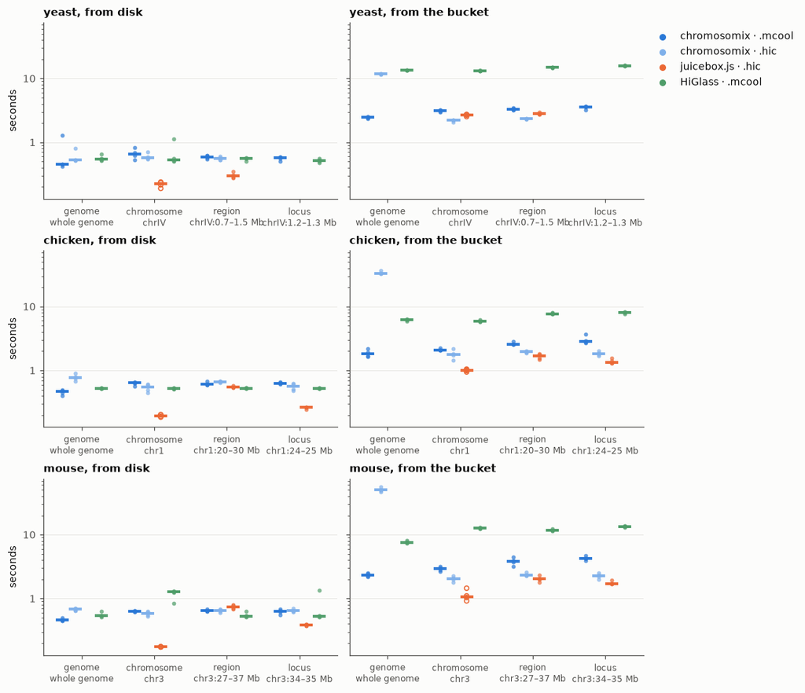

Figure 1: Seconds from handing each viewer its files to its picture being finished, every run a dot and the median a bar, on a logarithmic axis, by genome (rows) and by where the files were read from (columns). An open dot is a run that drew part of the window, or at another resolution; a view with no dots for a viewer is one it cannot draw at that resolution (the table above).

```python
VIEWER_COLOURS = {('chromosomix', 'mcool'): APP_COLOUR, ('chromosomix', 'hic'): '#7fb0ea',
                  ('juicebox', 'hic'): REF, ('higlass', 'mcool'): '#4f9d69'}
fig, axes = plt.subplots(len(GENOMES), len(LOCATIONS), figsize=(10, 2.6 * len(GENOMES) + 0.8), sharey=True,
                         layout='constrained', squeeze=False)
OFFSET = {key: (k - (len(VIEWERS) - 1) / 2) * 0.18 for k, key in enumerate(VIEWERS)}
for (r, genome), (c, location) in [(rc, lc) for rc in enumerate(GENOMES) for lc in enumerate(LOCATIONS)]:
    ax = axes[r][c]
    here = drew[(drew['genome'] == genome) & (drew['location'] == location)]
    for x, view in enumerate(VIEWS):
        for key in VIEWERS:
            rows = here[(here['view'] == view) & (here['viewer'] == key[0]) & (here['format'] == key[1])]
            if rows.empty:
                continue
            at = x + OFFSET[key]
            whole = rows['status'] == 'drawn'
            colour = VIEWER_COLOURS[key]
            ax.scatter(np.full(whole.sum(), at), rows.loc[whole, 'seconds'], s=14, color=colour, alpha=0.7, lw=0,
                       zorder=3)
            ax.scatter(np.full((~whole).sum(), at), rows.loc[~whole, 'seconds'], s=16, facecolors='none',
                       edgecolors=colour, lw=1, zorder=3)
            ax.plot([at - 0.07, at + 0.07], [rows['seconds'].median()] * 2, color=colour, lw=2.5, zorder=4)
    ax.set_xticks(range(len(VIEWS)), [f"{v}\n{next(w['label'] for w in GENOMES[genome]['views'] if w['view'] == v)}"
                                      for v in VIEWS], fontsize=8)
    ax.set_yscale('log')
    ax.yaxis.set_major_formatter(FuncFormatter(lambda v, _: f'{v:g}'))
    ax.set_title(f'{genome}, {WHERE[location]}')
    ax.grid(axis='x', visible=False)
    if c == 0:
        ax.set_ylabel('seconds')
for key in VIEWERS:
    axes[0][-1].scatter([], [], s=24, color=VIEWER_COLOURS[key], label=COLUMN[key])
axes[0][-1].legend(loc='upper left', bbox_to_anchor=(1, 1))
plt.show()
```

### Same file, other viewer

Where two viewers read the same file — juicebox.js and chromosomix the `.hic`, HiGlass and chromosomix the `.mcool` — and both drew the whole window at the resolution asked for in every run, the other viewer’s median time over chromosomix’s, picture by picture: above 1, chromosomix was the faster.

```python
def against(other, form):
    """The other viewer's median seconds over chromosomix's on the same file, for each picture both drew whole."""
    out = []
    for (genome, view, location), rows in timed_runs.groupby(['genome', 'view', 'location'], sort=False):
        mine = rows[(rows['viewer'] == 'chromosomix') & (rows['format'] == form)]
        theirs = rows[(rows['viewer'] == other) & (rows['format'] == form)]
        whole = (mine['status'] == 'drawn').all() and (theirs['status'] == 'drawn').all()
        if mine.empty or theirs.empty or not whole:
            continue
        out.append({'genome': genome, 'view': view, 'from': WHERE[location], 'file': f'.{form}',
                    'other viewer': NAMES[other], 'chromosomix s': mine['seconds'].median(),
                    'other s': theirs['seconds'].median()})
    return out


SAME = pd.DataFrame(against('juicebox', 'hic') + against('higlass', 'mcool'))
SAME['× faster'] = SAME['other s'] / SAME['chromosomix s']
show(SAME, **{'× faster': '{:.2f}×'})
```

| genome | view | from | file | other viewer | chromosomix s | other s | × faster |
| --- | --- | --- | --- | --- | --- | --- | --- |
| yeast | region | from disk | .hic | juicebox.js | 0.55 | 0.30 | 0.54× |
| yeast | region | from the bucket | .hic | juicebox.js | 2.35 | 2.81 | 1.20× |
| chicken | region | from disk | .hic | juicebox.js | 0.66 | 0.54 | 0.82× |
| chicken | region | from the bucket | .hic | juicebox.js | 1.96 | 1.67 | 0.85× |
| chicken | locus | from disk | .hic | juicebox.js | 0.56 | 0.26 | 0.47× |
| chicken | locus | from the bucket | .hic | juicebox.js | 1.83 | 1.35 | 0.73× |
| mouse | region | from disk | .hic | juicebox.js | 0.64 | 0.73 | 1.14× |
| mouse | region | from the bucket | .hic | juicebox.js | 2.34 | 2.02 | 0.86× |
| mouse | locus | from disk | .hic | juicebox.js | 0.64 | 0.38 | 0.60× |
| mouse | locus | from the bucket | .hic | juicebox.js | 2.28 | 1.71 | 0.75× |
| yeast | genome | from disk | .mcool | HiGlass | 0.45 | 0.54 | 1.19× |
| yeast | genome | from the bucket | .mcool | HiGlass | 2.45 | 13.42 | 5.48× |
| yeast | chromosome | from disk | .mcool | HiGlass | 0.66 | 0.54 | 0.82× |
| yeast | chromosome | from the bucket | .mcool | HiGlass | 3.10 | 13.21 | 4.27× |
| yeast | region | from disk | .mcool | HiGlass | 0.59 | 0.56 | 0.94× |
| yeast | region | from the bucket | .mcool | HiGlass | 3.29 | 14.92 | 4.54× |
| yeast | locus | from disk | .mcool | HiGlass | 0.57 | 0.51 | 0.90× |
| yeast | locus | from the bucket | .mcool | HiGlass | 3.60 | 15.81 | 4.39× |
| chicken | genome | from disk | .mcool | HiGlass | 0.46 | 0.52 | 1.13× |
| chicken | genome | from the bucket | .mcool | HiGlass | 1.81 | 6.22 | 3.44× |
| chicken | chromosome | from disk | .mcool | HiGlass | 0.64 | 0.52 | 0.82× |
| chicken | chromosome | from the bucket | .mcool | HiGlass | 2.08 | 5.85 | 2.81× |
| chicken | region | from disk | .mcool | HiGlass | 0.61 | 0.53 | 0.87× |
| chicken | region | from the bucket | .mcool | HiGlass | 2.59 | 7.75 | 2.99× |
| chicken | locus | from disk | .mcool | HiGlass | 0.63 | 0.52 | 0.83× |
| chicken | locus | from the bucket | .mcool | HiGlass | 2.83 | 8.06 | 2.84× |
| mouse | genome | from disk | .mcool | HiGlass | 0.46 | 0.54 | 1.17× |
| mouse | genome | from the bucket | .mcool | HiGlass | 2.34 | 7.58 | 3.24× |
| mouse | chromosome | from disk | .mcool | HiGlass | 0.63 | 1.28 | 2.03× |
| mouse | chromosome | from the bucket | .mcool | HiGlass | 2.91 | 12.62 | 4.34× |
| mouse | region | from disk | .mcool | HiGlass | 0.65 | 0.53 | 0.82× |
| mouse | region | from the bucket | .mcool | HiGlass | 3.82 | 11.66 | 3.05× |
| mouse | locus | from disk | .mcool | HiGlass | 0.63 | 0.53 | 0.84× |
| mouse | locus | from the bucket | .mcool | HiGlass | 4.22 | 13.52 | 3.21× |

```python
def geomean(values):
    return float(np.exp(np.log(np.asarray(values, dtype=float)).mean()))


def summary(other, location):
    rows = SAME[(SAME['other viewer'] == NAMES[other]) & (SAME['from'] == WHERE[location])]
    if rows.empty:
        return 'no picture both drew whole'
    return (f"{geomean(rows['× faster']):.2f}× over {len(rows)} pictures "
            f"({rows['× faster'].min():.2f}× to {rows['× faster'].max():.2f}×)")


V_TEXT = {'juicebox_local': summary('juicebox', 'local'), 'juicebox_cloud': summary('juicebox', 'cloud'),
          'higlass_local': summary('higlass', 'local'), 'higlass_cloud': summary('higlass', 'cloud')}
SLOWEST = drew.loc[drew['seconds'].idxmax()] if not drew.empty else None
V_TEXT['slowest'] = ('' if SLOWEST is None else
                     f"{SLOWEST['genome']}, {SLOWEST['view']} view, {NAMES[SLOWEST['viewer']]} on the "
                     f".{SLOWEST['format']} {WHERE[SLOWEST['location']]}: {SLOWEST['seconds']:.1f} s, "
                     f"{SLOWEST['requests']:.0f} requests")
```

### What it read, and the pages themselves

Requests and megabytes the page asked for before its picture was finished, median over the runs from the bucket; and each viewer’s page, loaded empty with its code, median seconds, which the times above leave out.

```python
CLOUD = drew[drew['location'] == 'cloud']
read = (CLOUD.assign(viewer=CLOUD['viewer'].map(NAMES))
        .groupby(['genome', 'view', 'viewer', 'format'], sort=False)
        .agg(requests=('requests', 'median'), megabytes=('megabytes', 'median')).reset_index())
display(show(read, requests='{:,.0f}', megabytes='{:,.1f}'))
pages = (timed_runs.assign(viewer=timed_runs['viewer'].map(NAMES), where=timed_runs['location'].map(WHERE))
         .groupby(['viewer', 'where'], sort=False)['app_seconds'].median().rename('page loaded, s').reset_index())
show(pages)
```

| genome | view | viewer | format | requests | megabytes |
| --- | --- | --- | --- | --- | --- |
| yeast | genome | chromosomix | mcool | 6 | 4.4 |
| yeast | genome | chromosomix | hic | 76 | 3.8 |
| yeast | genome | HiGlass | mcool | 4 | 0.9 |
| yeast | chromosome | chromosomix | mcool | 9 | 9.7 |
| yeast | chromosome | chromosomix | hic | 5 | 2.5 |
| yeast | chromosome | juicebox.js | hic | 11 | 12.8 |
| yeast | chromosome | HiGlass | mcool | 4 | 1.1 |
| yeast | region | chromosomix | mcool | 12 | 12.0 |
| yeast | region | chromosomix | hic | 6 | 2.8 |
| yeast | region | juicebox.js | hic | 11 | 12.8 |
| yeast | region | HiGlass | mcool | 4 | 0.5 |
| yeast | locus | chromosomix | mcool | 13 | 14.3 |
| yeast | locus | HiGlass | mcool | 4 | 0.5 |
| chicken | genome | chromosomix | mcool | 9 | 6.8 |
| chicken | genome | chromosomix | hic | 434 | 30.3 |
| chicken | genome | HiGlass | mcool | 4 | 0.9 |
| chicken | chromosome | chromosomix | mcool | 12 | 9.1 |
| chicken | chromosome | chromosomix | hic | 8 | 19.6 |
| chicken | chromosome | juicebox.js | hic | 11 | 0.9 |
| chicken | chromosome | HiGlass | mcool | 4 | 0.5 |
| chicken | region | chromosomix | mcool | 18 | 18.9 |
| chicken | region | chromosomix | hic | 8 | 21.5 |
| chicken | region | juicebox.js | hic | 16 | 2.7 |
| chicken | region | HiGlass | mcool | 4 | 0.5 |
| chicken | locus | chromosomix | mcool | 19 | 18.4 |
| chicken | locus | chromosomix | hic | 8 | 20.4 |
| chicken | locus | juicebox.js | hic | 16 | 1.1 |
| chicken | locus | HiGlass | mcool | 4 | 1.1 |
| mouse | genome | chromosomix | mcool | 11 | 8.8 |
| mouse | genome | chromosomix | hic | 460 | 21.5 |
| mouse | genome | HiGlass | mcool | 4 | 1.9 |
| mouse | chromosome | chromosomix | mcool | 20 | 21.0 |
| mouse | chromosome | chromosomix | hic | 8 | 20.4 |
| mouse | chromosome | juicebox.js | hic | 11 | 0.6 |
| mouse | chromosome | HiGlass | mcool | 4 | 1.6 |
| mouse | region | chromosomix | mcool | 26 | 32.0 |
| mouse | region | chromosomix | hic | 10 | 22.0 |
| mouse | region | juicebox.js | hic | 16 | 3.5 |
| mouse | region | HiGlass | mcool | 4 | 0.5 |
| mouse | locus | chromosomix | mcool | 28 | 29.1 |
| mouse | locus | chromosomix | hic | 10 | 21.8 |
| mouse | locus | juicebox.js | hic | 16 | 1.5 |
| mouse | locus | HiGlass | mcool | 4 | 1.1 |

| viewer | where | page loaded, s |
| --- | --- | --- |
| chromosomix | from disk | 0.15 |
| HiGlass | from disk | 0.23 |
| chromosomix | from the bucket | 0.14 |
| HiGlass | from the bucket | 0.23 |
| juicebox.js | from disk | 0.15 |
| juicebox.js | from the bucket | 0.16 |

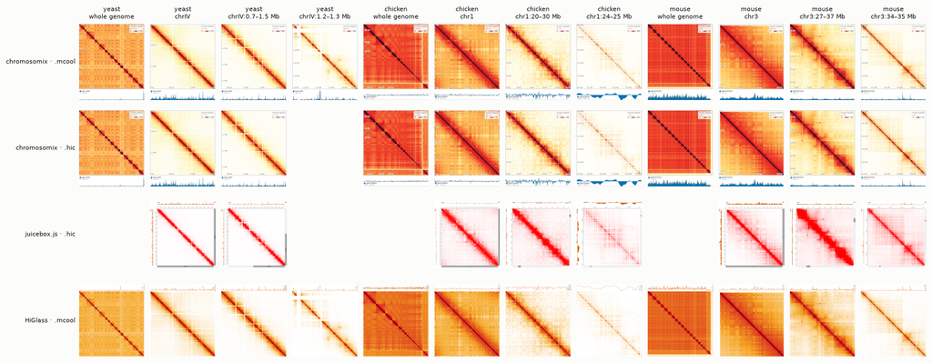

Figure 2: What each viewer had drawn when it said its picture was finished: the first round, from disk, cropped to the map and its track. Each column is a picture, each row a viewer and the file it read; an empty cell is a view the viewer cannot draw at the resolution asked for.

```python
from PIL import Image

PICTURE_KEYS = [(genome, view['view'], view['label']) for genome in GENOMES for view in GENOMES[genome]['views']]
fig, axes = plt.subplots(len(VIEWERS), len(PICTURE_KEYS), layout='constrained', squeeze=False,
                         figsize=(1.2 * len(PICTURE_KEYS) + 1, 1.35 * len(VIEWERS) + 0.6))
for c, (genome, view, label) in enumerate(PICTURE_KEYS):
    for r, (tool, form) in enumerate(VIEWERS):
        ax = axes[r][c]
        ax.set_xticks([])
        ax.set_yticks([])
        ax.grid(False)
        for side in ax.spines.values():
            side.set_visible(False)
        picture = f'{genome}-{view}-{tool}-{form}-local'
        shot = VIEWER_SHOTS / f'{picture}.png'
        if shot.exists() and picture in CLIPS:
            clip = CLIPS[picture]
            image = Image.open(shot).crop((round(clip['x']), round(clip['y']), round(clip['x'] + clip['width']),
                                           round(clip['y'] + clip['height'])))
            image.thumbnail((360, 360))
            ax.imshow(image)
        if r == 0:
            ax.set_title(f'{genome}\n{label}', fontsize=7, fontweight='normal', loc='center')
        if c == 0:
            ax.set_ylabel(COLUMN[(tool, form)], fontsize=7, rotation=0, ha='right', va='center')
plt.show()
```

## The machine

```python
if not MANIFEST.exists():
    raise FileNotFoundError(f'{MANIFEST} is not there: render validation.qmd first.')
LISTED = json.loads(MANIFEST.read_text())
OUT = LISTED['placeholder']
JOBS = [job for job in LISTED['commands'] if job['bench']]
measures({**MACHINE, 'commands timed': f"{len(JOBS)} of the {len(LISTED['commands'])} listed",
          'runs of each': RUNS, 'chromosomix': LISTED['chromosomix'],
          'processes a reference was given, where it takes them': LISTED['threads'],
          'peak memory': (f'every process of a run together, weighed every {EVERY} s' if WEIGHS
                          else 'the largest process of a run alone')})
```

| measure | value |
| --- | --- |
| processor | AMD EPYC 9V45 96-Core Processor |
| cores | 4 |
| memory_gb | 16.800000 |
| system | Linux-7.0.0-1017-azure-x86_64-with-glibc2.39 |
| node | v24.22.1 |
| python | 3.13.17 |
| commands timed | 95 of the 158 listed |
| runs of each | 4 |
| chromosomix | 0.18.0 at b1f1a7a |
| processes a reference was given, where it takes them | 4 |
| peak memory | every process of a run together, weighed every 0.25 s |

## The runs

Each command is run as `validation.qmd` printed it, from `notebooks/work/validation/`, with its output sent to a scratch folder that is emptied after the run: all of them once, then all of them again, so a slow minute of the machine falls on every command rather than on one. `chromosomix` computes on one thread; a reference that takes a number of processes was given the number in the `threads` column.

**The two sides of a pair take turns to go first.** The list has each analysis’s `chromosomix` commands before its references, and the odd rounds run it so; the even rounds run each analysis’s references first, each side’s commands still in their own order. Whichever side runs first reads from the disk whatever of their shared input the page cache has let go since the round before, and the side after it finds it in memory. Run in one order, that wait fell on `chromosomix` every time: a metaplot whose bigWig had gone from the cache spent twelve seconds of its wall clock waiting on it, and `computeMatrix`, straight after, none. In turns, it falls on each side in half the rounds, which is why the number of rounds is even.

```python
def argv_for(job, scratch):
    """The command as it ran, writing to `scratch`."""
    if job['tool'] == 'chromosomix':
        return job['argv'] + ['--out', os.path.relpath(scratch, WORK)]
    target = os.path.relpath(scratch / job['out'], WORK)
    return [a.replace(OUT, target) for a in job['argv']]


def under(pid):
    """`pid` and every process under it, by the children each of their threads started."""
    found, todo = [], [pid]
    while todo:
        pid = todo.pop()
        found.append(pid)
        try:
            for tid in os.listdir(f'/proc/{pid}/task'):
                with open(f'/proc/{pid}/task/{tid}/children') as handle:
                    todo += [int(child) for child in handle.read().split()]
        except OSError:
            pass
    return found


def pss_kb(pid):
    """A process's proportional set size, in kB: its resident pages, one it shares with others counted as its
    share of it, so that a pool of forked workers is not counted again in each."""
    try:
        with open(f'/proc/{pid}/smaps_rollup') as handle:
            return next(int(line.split()[1]) for line in handle if line.startswith('Pss:'))
    except (OSError, StopIteration):
        return 0


def weigh(pid, done, peak):
    """Every EVERY seconds until `done`, the processes under `pid` weighed together, the most into `peak[0]`."""
    while True:
        peak[0] = max(peak[0], sum(pss_kb(p) for p in under(pid)))
        if done.wait(EVERY):
            return


def timed(argv, extra):
    """One run, from work/validation/: CPU seconds of the process and every process it started and waited
    for, wall seconds, and the most memory they held together, in MB."""
    env = None if extra is None else dict(os.environ, **extra)
    with tempfile.TemporaryFile() as err:
        start = time.perf_counter()
        process = subprocess.Popen(argv, cwd=WORK, env=env, stdout=subprocess.DEVNULL, stderr=err)
        done, peak = threading.Event(), [0]
        weigher = threading.Thread(target=weigh, args=(process.pid, done, peak), daemon=True)
        if WEIGHS:
            weigher.start()
        _, status, usage = os.wait4(process.pid, 0)
        wall = time.perf_counter() - start
        done.set()
        if WEIGHS:
            weigher.join()
        process.returncode = os.waitstatus_to_exitcode(status)
        if process.returncode:
            err.seek(0)
            raise RuntimeError(f'{shlex.join(argv)}\n{err.read().decode(errors="replace")[-3000:]}')
    # ru_maxrss, the largest resident set any one of the processes reached, which a sample can miss: in
    # kilobytes on Linux and in bytes on macOS.
    largest = usage.ru_maxrss / (1024 * 1024 if sys.platform == 'darwin' else 1024)
    return {'cpu_s': usage.ru_utime + usage.ru_stime, 'user_s': usage.ru_utime, 'system_s': usage.ru_stime,
            'wall_s': wall, 'peak_mb': max(peak[0] / 1024, largest)}


#: The columns of the table, in order: what was run, the run, what it cost, where.
COLUMNS = ['section', 'analysis', 'data', 'command', 'tool', 'version', 'variant', 'group', 'threads', 'run',
           'order', 'cpu_s', 'user_s', 'system_s', 'wall_s', 'peak_mb', 'started', *MACHINE, 'chromosomix',
           'command_line']


def round_of(run):
    """The jobs round `run` runs, in its order, each with its place in the list (`order`): as listed on an
    odd round, each analysis's chromosomix commands before its references, and on an even one each
    analysis's references first, each side's commands in their own order."""
    listed = list(enumerate(JOBS))
    if run % 2 == 1:
        return listed
    turned = []
    for _, analysis in groupby(listed, key=lambda pair: (pair[1]['section'], pair[1]['analysis'])):
        analysis = list(analysis)
        turned += [pair for pair in analysis if pair[1]['tool'] != 'chromosomix']
        turned += [pair for pair in analysis if pair[1]['tool'] == 'chromosomix']
    return turned


def benchmark():
    rows = []
    for run in range(1, RUNS + 1):
        for order, job in round_of(run):
            scratch = SCRATCH / job['name']
            shutil.rmtree(scratch, ignore_errors=True)
            scratch.mkdir(parents=True)
            started = time.strftime('%Y-%m-%dT%H:%M:%S')
            cost = timed(argv_for(job, scratch), job['env'])
            shutil.rmtree(scratch, ignore_errors=True)
            rows.append({'section': job['section'], 'analysis': job['analysis'], 'data': job['data'],
                         'command': job['name'], 'tool': job['tool'], 'version': job['version'],
                         'variant': job['variant'], 'group': job['group'], 'threads': job['threads'], 'run': run,
                         'order': order, **cost, 'started': started, **MACHINE,
                         'chromosomix': LISTED['chromosomix'], 'command_line': job['command']})
        # Written after every round, so a long benchmark that is stopped keeps the rounds it finished.
        pd.DataFrame(rows, columns=COLUMNS).to_csv(TIMINGS, sep='\t', index=False)
    return pd.DataFrame(rows, columns=COLUMNS)


def current():
    """Whether the table on disk times every command listed, each RUNS times, with the chromosomix listed, in
    this notebook's columns."""
    if REDO or not TIMINGS.exists():
        return False
    held = pd.read_csv(TIMINGS, sep='\t', keep_default_na=False)
    if list(held.columns) != COLUMNS:
        return False
    runs = held.groupby('order')['run'].nunique()
    return (len(runs) == len(JOBS) and set(held['command']) == {job['name'] for job in JOBS}
            and (runs == RUNS).all() and set(held['chromosomix']) == {LISTED['chromosomix']})


if not current():
    SCRATCH.mkdir(parents=True, exist_ok=True)
    benchmark()
times = pd.read_csv(TIMINGS, sep='\t', keep_default_na=False)
measures({'runs in the table': f'{len(times):,}', 'columns': len(times.columns),
          'measured': f"{times['started'].min()} to {times['started'].max()}", 'table': os.path.relpath(TIMINGS, REPO)})
```

| measure | value |
| --- | --- |
| runs in the table | 380 |
| columns | 25 |
| measured | 2026-10-30T11:00:20 to 2026-10-30T12:52:01 |
| table | notebooks/work/validation/timings.tsv |

The table’s first lines:

```python
show(times.head(4))
```

| section | analysis | data | command | tool | version | variant | group | threads | run | order | cpu_s | user_s | system_s | wall_s | peak_mb | started | processor | cores | memory_gb | system | node | python | chromosomix | command_line |
| --- | --- | --- | --- | --- | --- | --- | --- | --- | --- | --- | --- | --- | --- | --- | --- | --- | --- | --- | --- | --- | --- | --- | --- | --- |
| 1 | Diamond insulation | mouse Hi-C, 10 kb, window 100 kb | insulation | chromosomix | 0.18.0 at b1f1a7a |  |  | 1 | 1 | 0 | 5.29 | 4.76 | 0.53 | 4.15 | 320.56 | 2026-10-30T11:00:20 | AMD EPYC 9V45 96-Core Processor | 4 | 16.80 | Linux-7.0.0-1017-azure-x86_64-with-glibc2.39 | v24.22.1 | 3.13.17 | 0.18.0 at b1f1a7a | chromosomix insulation data/4DNFIOZ1TRUS.mcool::/resolutions/10000 --window 10 --out insulation/app |
| 1 | Diamond insulation | mouse Hi-C, 10 kb, window 100 kb | cooltools-insulation | cooltools | 0.7.1 |  |  | 4 | 1 | 1 | 12.39 | 11.52 | 0.87 | 6.20 | 907.41 | 2026-10-30T11:00:24 | AMD EPYC 9V45 96-Core Processor | 4 | 16.80 | Linux-7.0.0-1017-azure-x86_64-with-glibc2.39 | v24.22.1 | 3.13.17 | 0.18.0 at b1f1a7a | python ../../scripts/cooltools_insulation.py data/4DNFIOZ1TRUS.mcool::/resolutions/10000 insulation/cooltools.tsv 4 |
| 2 | Directionality index | mouse Hi-C, 50 kb, window 2 Mb | di | chromosomix | 0.18.0 at b1f1a7a |  |  | 1 | 1 | 2 | 2.50 | 2.31 | 0.19 | 1.91 | 213.30 | 2026-10-30T11:00:30 | AMD EPYC 9V45 96-Core Processor | 4 | 16.80 | Linux-7.0.0-1017-azure-x86_64-with-glibc2.39 | v24.22.1 | 3.13.17 | 0.18.0 at b1f1a7a | chromosomix di data/4DNFIOZ1TRUS.mcool::/resolutions/50000 --window 40 --out di/app |
| 2 | Directionality index | mouse Hi-C, 50 kb, window 2 Mb | domaincaller-di | domaincaller | 0.1.0 |  |  | 1 | 1 | 3 | 2.83 | 2.67 | 0.16 | 2.53 | 259.77 | 2026-10-30T11:00:32 | AMD EPYC 9V45 96-Core Processor | 4 | 16.80 | Linux-7.0.0-1017-azure-x86_64-with-glibc2.39 | v24.22.1 | 3.13.17 | 0.18.0 at b1f1a7a | python ../../scripts/domaincaller_di.py data/4DNFIOZ1TRUS.mcool::/resolutions/50000 di/domaincaller.npy |

## Each command

CPU and wall-clock seconds, mean ± sd over the runs, and the peak memory of the largest run.

```python
KEY = ['section', 'analysis', 'tool', 'variant', 'group', 'command', 'order']
per = (times.groupby(KEY, sort=False)
       .agg(cpu=('cpu_s', 'mean'), cpu_sd=('cpu_s', 'std'), wall=('wall_s', 'mean'), wall_sd=('wall_s', 'std'),
            peak=('peak_mb', 'max'))
       .reset_index().sort_values('order').reset_index(drop=True))
per['CPU s'] = [f'{m:.2f} ± {s:.2f}' for m, s in zip(per['cpu'], per['cpu_sd'])]
per['wall s'] = [f'{m:.2f} ± {s:.2f}' for m, s in zip(per['wall'], per['wall_sd'])]
per['peak MB'] = per['peak'].round().astype(int)
show(per[['section', 'analysis', 'tool', 'variant', 'CPU s', 'wall s', 'peak MB']], **{'peak MB': '{:,}'})
```

| section | analysis | tool | variant | CPU s | wall s | peak MB |
| --- | --- | --- | --- | --- | --- | --- |
| 1 | Diamond insulation | chromosomix |  | 5.11 ± 0.16 | 4.02 ± 0.10 | 333 |
| 1 | Diamond insulation | cooltools |  | 12.31 ± 0.31 | 5.65 ± 0.43 | 907 |
| 2 | Directionality index | chromosomix |  | 2.53 ± 0.10 | 1.89 ± 0.04 | 232 |
| 2 | Directionality index | domaincaller |  | 2.86 ± 0.10 | 2.57 ± 0.10 | 260 |
| 3 | Compartments | chromosomix |  | 6.00 ± 0.14 | 4.33 ± 0.09 | 317 |
| 3 | Compartments | cooltools |  | 15.22 ± 0.80 | 8.08 ± 0.55 | 562 |
| 4 | P(s) | chromosomix | yeast 800 bp | 0.76 ± 0.02 | 0.56 ± 0.01 | 213 |
| 4 | P(s) | chromosomix | mouse 10 kb | 3.00 ± 0.07 | 2.49 ± 0.05 | 239 |
| 4 | P(s) | cooltools | yeast 800 bp | 3.25 ± 0.18 | 2.61 ± 0.17 | 1,064 |
| 4 | P(s) | cooltools | mouse 10 kb | 26.05 ± 1.66 | 10.51 ± 2.32 | 11,829 |
| 5 | Peak calling (yapc, IDR) | chromosomix |  | 20.44 ± 0.71 | 18.66 ± 0.51 | 294 |
| 5 | Peak calling (yapc, IDR) | yapc 0.1 | seed 0 | 62.66 ± 0.62 | 62.75 ± 0.64 | 1,668 |
| 6 | Loops (chromosight) | chromosomix |  | 6.31 ± 0.16 | 5.17 ± 0.08 | 284 |
| 6 | Loops (chromosight) | chromosight |  | 31.70 ± 0.94 | 11.04 ± 0.47 | 772 |
| 7 | Reproducibility (HiCRep) | chromosomix | 3 maps, 3 pairs | 4.21 ± 0.21 | 3.36 ± 0.17 | 266 |
| 7 | Reproducibility (HiCRep) | hicrep | 3 maps, 3 pairs | 5.73 ± 0.24 | 5.45 ± 0.24 | 273 |
| 8 | 3D model (pastis-NB) | chromosomix | seed 0 | 5.94 ± 0.17 | 5.62 ± 0.15 | 213 |
| 8 | 3D model (pastis-NB) | pastis | seed 0 | 85.21 ± 1.25 | 31.18 ± 1.02 | 361 |
| 9 | Coverage | chromosomix | raw | 3.91 ± 0.17 | 3.25 ± 0.16 | 373 |
| 9 | Coverage | chromosomix | balanced | 4.17 ± 0.25 | 3.47 ± 0.22 | 292 |
| 9 | Coverage | cooltools | raw | 6.07 ± 0.39 | 2.88 ± 0.28 | 1,476 |
| 9 | Coverage | cooltools | balanced | 6.57 ± 0.24 | 3.23 ± 0.20 | 1,854 |
| 10 | Virtual 4C | chromosomix | Sox2 | 1.30 ± 0.06 | 0.98 ± 0.04 | 248 |
| 10 | Virtual 4C | cooltools | Sox2 | 7.14 ± 0.26 | 3.03 ± 0.18 | 554 |
| 11 | Aggregate peak analysis | chromosomix | raw | 1.43 ± 0.07 | 0.97 ± 0.03 | 213 |
| 11 | Aggregate peak analysis | chromosomix | raw, every loop | 2.08 ± 0.13 | 1.48 ± 0.07 | 213 |
| 11 | Aggregate peak analysis | chromosomix | on the diagonal, raw | 2.30 ± 0.16 | 1.61 ± 0.08 | 217 |
| 11 | Aggregate peak analysis | chromosomix | controls, seed 1 | 2.47 ± 0.14 | 1.75 ± 0.08 | 213 |
| 11 | Aggregate peak analysis | coolpuppy | raw | 8.78 ± 0.19 | 3.53 ± 0.14 | 913 |
| 11 | Aggregate peak analysis | coolpuppy | raw, every loop | 9.16 ± 0.30 | 3.65 ± 0.18 | 1,001 |

[output cut: 65 more lines]

## Against the references

For each analysis, the `chromosomix` commands against the reference commands they are paired with — the same variant, or the analysis’s one reference — as a fold: the reference’s seconds over the app’s, summed where a side is several commands, which the table names. deepTools’ metaplot is `computeMatrix` and then `plotProfile` — and `plotHeatmap`, over two tracks — against one `chromosomix metaplot`; its track correlation is `multiBigwigSummary` and then `plotCorrelation` once a method, against `chromosomix trackcorr` once a method.

```python
#: Each timed command's line, by its name, for what the pairs below add up.
LINES = {job['name']: job['command'] for job in JOBS}


def program(name):
    """What a timed command runs: chromosomix's task, a reference script's name, or the program."""
    words = shlex.split(LINES[name])
    if words[0] == 'chromosomix':
        return words[1]
    if words[0].endswith('python'):
        return Path(words[1]).stem
    return words[0]


def summed(rows):
    """The commands one side of a pair adds up, in order, a repeated one counted: `plotCorrelation ×2`."""
    counts = Counter(program(name) for name in rows['command'])
    return ' + '.join(name if n == 1 else f'{name} ×{n}' for name, n in counts.items())


def pairs():
    out = []
    for (section, analysis), rows in per.groupby(['section', 'analysis'], sort=False):
        apps, refs = rows[rows['tool'] == 'chromosomix'], rows[rows['tool'] != 'chromosomix']
        for group, mine in apps.groupby('group', sort=False):
            theirs = refs[refs['group'] == group]
            if theirs.empty and refs['group'].nunique() == 1:
                theirs = refs
            if theirs.empty:
                continue
            out.append({'section': section, 'analysis': analysis, 'variant': group or '—',
                        'reference': ', '.join(dict.fromkeys(theirs['tool'])),
                        'chromosomix commands': summed(mine), 'reference commands': summed(theirs),
                        'chromosomix CPU s': mine['cpu'].sum(), 'reference CPU s': theirs['cpu'].sum(),
                        'chromosomix wall s': mine['wall'].sum(), 'reference wall s': theirs['wall'].sum(),
                        'chromosomix peak MB': mine['peak'].max(), 'reference peak MB': theirs['peak'].max()})
    frame = pd.DataFrame(out)
    frame['× faster, CPU'] = frame['reference CPU s'] / frame['chromosomix CPU s']
    frame['× faster, wall'] = frame['reference wall s'] / frame['chromosomix wall s']
    return frame


folds = pairs()
show(folds, **{'× faster, CPU': '{:.1f}×', '× faster, wall': '{:.1f}×', 'chromosomix peak MB': '{:,.0f}',
               'reference peak MB': '{:,.0f}'})
```

| section | analysis | variant | reference | chromosomix commands | reference commands | chromosomix CPU s | reference CPU s | chromosomix wall s | reference wall s | chromosomix peak MB | reference peak MB | × faster, CPU | × faster, wall |
| --- | --- | --- | --- | --- | --- | --- | --- | --- | --- | --- | --- | --- | --- |
| 1 | Diamond insulation | — | cooltools | insulation | cooltools_insulation | 5.11 | 12.31 | 4.02 | 5.65 | 333 | 907 | 2.4× | 1.4× |
| 2 | Directionality index | — | domaincaller | di | domaincaller_di | 2.53 | 2.86 | 1.89 | 2.57 | 232 | 260 | 1.1× | 1.4× |
| 3 | Compartments | — | cooltools | compartments | cooltools_eigs_cis | 6.00 | 15.22 | 4.33 | 8.08 | 317 | 562 | 2.5× | 1.9× |
| 4 | P(s) | yeast 800 bp | cooltools | expected | cooltools_expected_cis | 0.76 | 3.25 | 0.56 | 2.61 | 213 | 1,064 | 4.3× | 4.6× |
| 4 | P(s) | mouse 10 kb | cooltools | expected | cooltools_expected_cis | 3.00 | 26.05 | 2.49 | 10.51 | 239 | 11,829 | 8.7× | 4.2× |
| 5 | Peak calling (yapc, IDR) | — | yapc 0.1 | peaks | yapc_idr | 20.44 | 62.66 | 18.66 | 62.75 | 294 | 1,668 | 3.1× | 3.4× |
| 6 | Loops (chromosight) | — | chromosight | chromosight | chromosight | 6.31 | 31.70 | 5.17 | 11.04 | 284 | 772 | 5.0× | 2.1× |
| 7 | Reproducibility (HiCRep) | 3 maps, 3 pairs | hicrep | hicrep_scc | hicrep_scc | 4.21 | 5.73 | 3.36 | 5.45 | 266 | 273 | 1.4× | 1.6× |
| 8 | 3D model (pastis-NB) | seed 0 | pastis | reconstruct3d | pastis_nb | 5.94 | 85.21 | 5.62 | 31.18 | 213 | 361 | 14.3× | 5.5× |
| 9 | Coverage | raw | cooltools | coverage | cooltools_coverage | 3.91 | 6.07 | 3.25 | 2.88 | 373 | 1,476 | 1.6× | 0.9× |
| 9 | Coverage | balanced | cooltools | coverage | cooltools_coverage | 4.17 | 6.57 | 3.47 | 3.23 | 292 | 1,854 | 1.6× | 0.9× |
| 10 | Virtual 4C | Sox2 | cooltools | fourc | cooltools_virtual4c | 1.30 | 7.14 | 0.98 | 3.03 | 248 | 554 | 5.5× | 3.1× |
| 11 | Aggregate peak analysis | raw | coolpuppy | apa | coolpuppy_pileup | 1.43 | 8.78 | 0.97 | 3.53 | 213 | 913 | 6.1× | 3.6× |
| 11 | Aggregate peak analysis | raw, every loop | coolpuppy | apa | coolpuppy_pileup | 2.08 | 9.16 | 1.48 | 3.65 | 213 | 1,001 | 4.4× | 2.5× |
| 11 | Aggregate peak analysis | on the diagonal, raw | coolpuppy | apa | coolpuppy_pileup | 2.30 | 9.35 | 1.61 | 3.70 | 217 | 1,005 | 4.1× | 2.3× |
| 11 | Aggregate peak analysis | controls | coolpuppy | apa | coolpuppy_pileup | 2.47 | 9.22 | 1.75 | 3.62 | 213 | 931 | 3.7× | 2.1× |
| 12 | APA, chromosight's score | — | chromosight | apa | chromosight | 5.23 | 84.59 | 3.83 | 26.86 | 242 | 1,493 | 16.2× | 7.0× |
| 13 | Boost-HiC | chr1, 1,955 bins | Boost-HiC | boost | boosthic | 3.65 | 20.15 | 3.41 | 19.63 | 638 | 464 | 5.5× | 5.8× |
| 14 | Metaplot | TSS | deepTools | metaplot | computeMatrix + plotProfile | 4.33 | 5.43 | 3.61 | 5.27 | 385 | 224 | 1.3× | 1.5× |
| 14 | Metaplot | TSS, two tracks | deepTools | metaplot | computeMatrix + plotProfile + plotHeatmap | 7.55 | 12.34 | 6.21 | 9.40 | 439 | 489 | 1.6× | 1.5× |
| 15 | Interval overlap | — | bedtools | overlap | bedtools_overlap | 1.08 | 44.67 | 1.00 | 40.14 | 213 | 213 | 41.3× | 40.0× |
| 16 | Base composition | — | bioframe, Biopython | composition | composition | 3.75 | 40.83 | 5.36 | 42.31 | 311 | 509 | 10.9× | 7.9× |
| 17 | Motif search | TGACTCA, ≤ 1 mismatch | seqkit | motif | seqkit | 5.46 | 18.63 | 5.45 | 18.40 | 360 | 4,119 | 3.4× | 3.4× |
| 17 | Motif search | WGATAR | seqkit | motif | seqkit | 4.09 | 6.49 | 4.04 | 6.22 | 318 | 343 | 1.6× | 1.5× |
| 18 | Track correlation | 100 bp windows | deepTools | trackcorr ×2 | multiBigwigSummary + plotCorrelation ×2 | 2.34 | 195.06 | 1.90 | 53.18 | 326 | 308 | 83.5× | 28.0× |
| 18 | Track correlation | 1,000 bp windows | deepTools | trackcorr ×2 | multiBigwigSummary + plotCorrelation ×2 | 1.57 | 21.10 | 1.09 | 6.69 | 213 | 213 | 13.4× | 6.2× |
| 18 | Track correlation | 10,000 bp windows | deepTools | trackcorr ×2 | multiBigwigSummary + plotCorrelation ×2 | 1.45 | 5.23 | 0.99 | 2.37 | 213 | 213 | 3.6× | 2.4× |
| 19 | Loop calling | — | cooltools | loops | cooltools_dots | 26.09 | 573.03 | 22.58 | 162.08 | 474 | 11,830 | 22.0× | 7.2× |
| 24 | CTCF sites in GM12878 (Fig. 2) | insulation | cooltools | insulation | cooltools_insulation_scales | 1.38 | 6.08 | 1.00 | 5.54 | 214 | 867 | 4.4× | 5.5× |
| 24 | CTCF sites in GM12878 (Fig. 2) | peaks | yapc 0.1 | peaks | yapc_idr | 39.15 | 81.00 | 36.77 | 81.11 | 233 | 1,596 | 2.1× | 2.2× |
| 24 | CTCF sites in GM12878 (Fig. 2) | APA | coolpuppy | apa ×2 | coolpuppy_pileup ×2 | 1.87 | 7.20 | 1.32 | 6.23 | 236 | 1,119 | 3.9× | 4.7× |
| 24 | CTCF sites in GM12878 (Fig. 2) | metaplot, signal | deepTools | metaplot | computeMatrix + plotProfile + plotHeatmap | 1.17 | 3.30 | 0.89 | 2.34 | 289 | 213 | 2.8× | 2.6× |
| 24 | CTCF sites in GM12878 (Fig. 2) | metaplot, insulation | deepTools | metaplot | computeMatrix + plotProfile + plotHeatmap | 1.28 | 42.15 | 1.04 | 13.31 | 213 | 946 | 32.8× | 12.8× |
| 25 | Pairs statistics | — | pairtools | stats | pairtools | 68.35 | 88.06 | 61.19 | 78.62 | 274 | 308 | 1.3× | 1.3× |
| 26 | Restriction sites | — | bioframe, Biopython | restriction | bioframe_digest | 1.14 | 1.21 | 1.09 | 0.90 | 213 | 213 | 1.1× | 0.8× |
| 27 | Pairs QC | — | cooler, pairtools, pandas, cooltools | pairsqc | cooler + pairtools ×3 + restriction_reference + cooltools_coverage_sites | 140.65 | 897.41 | 125.34 | 614.71 | 337 | 2,364 | 6.4× | 4.9× |

```python
fold = folds['× faster, CPU']
TEXT = {'fold': f'{np.exp(np.log(fold).mean()):.1f}', 'n': f'{len(fold)}',
        'range': f'{fold.min():.1f}× to {fold.max():.1f}×',
        'slower': ', '.join(f"{a} ({v})" for a, v, f in zip(folds['analysis'], folds['variant'], fold) if f < 1) or 'none',
        'sd': f"{(per['cpu_sd'] / per['cpu']).max():.0%}",
        'wall': f"{np.exp(np.log(folds['× faster, wall']).mean()):.1f}"}
```

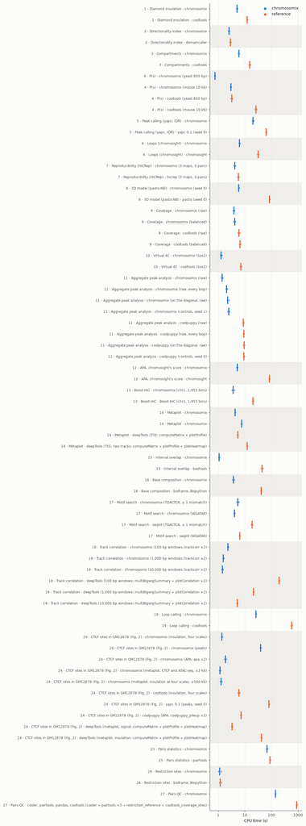

Figure 3: CPU time of every job, one row a side of a pair in the table above, its commands added up run by run (deepTools’ computeMatrix and plotProfile on one line); each run a dot and the mean a bar, on a logarithmic axis; the rows of one analysis share a band.

```python
def jobs():
    """One row a side of each pair: an analysis's chromosomix commands of one group, or its reference's, with
    every run's CPU seconds added up across them, as the pairs above add them."""
    side = np.where(per['tool'] == 'chromosomix', 'chromosomix', 'reference')
    out = []
    for (section, analysis, _, group), rows in per.groupby(['section', 'analysis', side, 'group'], sort=False):
        # By their places in the list: an analysis may give its chromosomix command and its reference one name.
        runs_ = times[times['order'].isin(rows['order'])].groupby('run')['cpu_s'].sum()
        groups = per.loc[(per['section'] == section) & (per['analysis'] == analysis), 'group'].nunique()
        if len(rows) == 1:
            what = rows['variant'].iloc[0]
        else:
            what = (f'{group}: ' if groups > 1 and group else '') + summed(rows)
        out.append({'section': section, 'analysis': analysis, 'tool': ', '.join(dict.fromkeys(rows['tool'])),
                    'what': what, 'runs': runs_.to_numpy(), 'cpu': runs_.mean()})
    return out


JOB_ROWS = jobs()
fig, ax = plt.subplots(figsize=(10, 0.36 * len(JOB_ROWS) + 1.2), layout='constrained')
y = np.arange(len(JOB_ROWS))[::-1]
BANDS = [row['analysis'] for row in JOB_ROWS]
for k, analysis in enumerate(dict.fromkeys(BANDS)):
    if k % 2:
        at = y[[i for i, one in enumerate(BANDS) if one == analysis]]
        ax.axhspan(at.min() - 0.5, at.max() + 0.5, color=MISSING, lw=0, zorder=0)
for yi, row in zip(y, JOB_ROWS):
    colour = APP_COLOUR if row['tool'] == 'chromosomix' else REF
    ax.scatter(row['runs'], np.full(len(row['runs']), yi), s=14, color=colour, alpha=0.55, lw=0, zorder=3)
    ax.plot([row['cpu']] * 2, [yi - 0.3, yi + 0.3], color=colour, lw=2.5, zorder=4)
labels = [f"{row['section']} · {row['analysis']} · {row['tool']}" + (f" ({row['what']})" if row['what'] else '')
          for row in JOB_ROWS]
ax.set_yticks(y, labels, fontsize=8)
ax.set_xscale('log')
EVERY = np.concatenate([row['runs'] for row in JOB_ROWS])
ax.set_xlim(EVERY.min() / 1.5, EVERY.max() * 1.5)
ax.xaxis.set_major_formatter(FuncFormatter(lambda v, _: f'{v:g}'))
ax.xaxis.set_minor_locator(NullLocator())
ax.set(xlabel='CPU time (s)', ylim=(-0.5, len(JOB_ROWS) - 0.5))
ax.grid(axis='y', visible=False)
ax.scatter([], [], s=24, color=APP_COLOUR, label='chromosomix')
ax.scatter([], [], s=24, color=REF, label='reference')
ax.legend(loc='upper right')
plt.show()
```

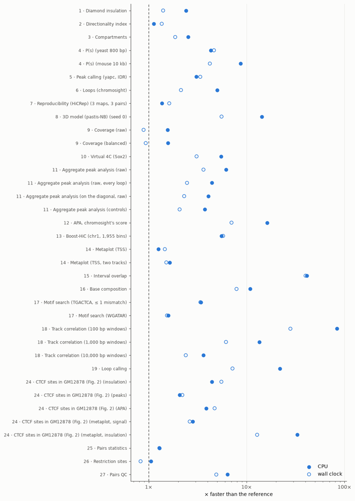

Figure 4: How many times less CPU (filled) and wall-clock time (open) chromosomix takes than its reference, pair by pair; right of the line is faster.

```python
fig, ax = plt.subplots(figsize=(9, 0.32 * len(folds) + 1.2), layout='constrained')
y = np.arange(len(folds))[::-1]
ax.scatter(folds['× faster, CPU'], y, s=36, color=APP_COLOUR, label='CPU', zorder=3)
ax.scatter(folds['× faster, wall'], y, s=36, facecolors='none', edgecolors=APP_COLOUR, label='wall clock', zorder=3)
ax.axvline(1, color=INK2, lw=1, ls=(0, (4, 3)))
ax.set_yticks(y, [f"{s} · {a}" + (f' ({v})' if v != '—' else '') for s, a, v in
                  zip(folds['section'], folds['analysis'], folds['variant'])], fontsize=8)
ax.set_xscale('log')
ax.xaxis.set_major_formatter(FuncFormatter(lambda v, _: f'{v:g}×'))
ax.set(xlabel='× faster than the reference', ylim=(-0.5, len(folds) - 0.5))
ax.grid(axis='y', visible=False)
ax.legend(loc='lower right')
plt.show()
```

*Rendered in 163 min 12 s, from 30 October 2026, 10:10 UTC to 12:54 UTC, by chromosomix 0.18.0 at `b1f1a7a`.*